# Házifeladat: Nemfizetett háztartási munka elemzése

A társadalomtudomány alapjai - 4. hét

Hallgató

2025-12-02

# 1. Bevezetés

## 1.1 A feladat célja

A házifeladat célja a **nemek szerint megbontott termelési koreloszlások egyesítése** az ENSZ népességadatainak felhasználásával. Ez azt jelenti, hogy a férfiak és nők által végzett nemfizetett háztartási munka életkor szerinti eloszlásait kombináljuk, figyelembe véve a népesség nemek és életkor szerinti megoszlását.

## 1.2 Felhasznált adatforrások

1. **Counting Women’s Work Database** (cww_database_PUBLIC_RELEASE_V3.0.xlsx)
   - A nemfizetett háztartási munka időben és pénzben mért értékei
   - Életkor és nem szerinti bontásban
2. **ENSZ Népességi adatok** (UN Population Division)
   - Népesség életkor és nem szerinti megoszlása
   - Világnépesség-előrejelzés adatai

# 2. Módszertan

## 2.1 A probléma megközelítése

A feladat megoldásához az alábbi lépéseket kell követni:

### 2.1.1 Adatok betöltése és előkészítése

Először be kell töltenünk mind a Counting Women’s Work adatbázist, mind az ENSZ népességi adatokat. A CWW adatbázis tartalmazza a nemfizetett háztartási munka értékeit életkor és nem szerint, míg az ENSZ adatok megadják, hogy egy adott országban hány férfi és nő él az egyes korcsoportokban.

### 2.1.2 A súlyozás logikája

A két nem eloszlásának egyesítéséhez **súlyozott átlagot** kell számolnunk. A súlyok a népesség nemek szerinti megoszlásából származnak.

**Matematikai képlet:**

$$P_{combined}(a) = \frac{P_{female}(a)
\times N_{female}(a) + P_{male}(a) \times N_{male}(a)}{N_{female}(a) +
N_{male}(a)}$$

Ahol: - $P_{combined}(a)$ = kombinált termelési érték az $a$ életkorban - $P_{female}(a)$ = női termelési érték az $a$ életkorban - $P_{male}(a)$ = férfi termelési érték az $a$ életkorban - $N_{female}(a)$ = nők száma az $a$ életkorban - $N_{male}(a)$ = férfiak száma az $a$ életkorban

### 2.1.3 Miért van szükség súlyozásra?

Ha egyszerűen átlagolnánk a férfi és női értékeket ($(P_{female} + P_{male})/2$), akkor azt feltételeznénk, hogy minden életkorban pontosan egyenlő számú férfi és nő van. Ez azonban nem igaz:

- Fiatalabb korokban (0-40 év) általában **több fiú születik** (természetes arány kb. 105:100)
- Idősebb korokban (70+ év) **több nő él**, mert a nők élettartama hosszabb

A népességi súlyozás biztosítja, hogy a kombinált eloszlás **reálisan tükrözze a teljes népesség háztartási munka-termelését**, figyelembe véve a nemek tényleges arányát minden életkorban.

## 2.2 Implementációs lépések

1. **Adatbetöltés**: CWW Excel fájl és ENSZ népességi adatok beolvasása
2. **Adattisztítás**: Hiányzó értékek kezelése, formátum-egységesítés
3. **Életkori csoportok harmonizálása**: Biztosítani, hogy mindkét adatforrás ugyanazokat a korcsoportokat használja
4. **Súlyozott kombinálás**: A fenti képlet alkalmazása minden életkorra
5. **Vizualizáció**: Az eredmények grafikus megjelenítése
6. **Értelmezés**: A kapott eloszlás összehasonlítása a nemi bontású eloszlásokkal

# 3. Adatok betöltése

```r
# Szükséges csomagok betöltése
library(readxl)      # Excel fájlok olvasásához
library(dplyr)       # Adatmanipulációhoz
library(tidyr)       # Adatok átrendezéséhez
library(ggplot2)     # Vizualizációhoz
library(scales)      # Skálák formázásához
```

```r
# Counting Women's Work adatbázis betöltése
cww_file <- "cww_database_PUBLIC_RELEASE_V3.0.xlsx"

# Ellenőrizzük, hogy létezik-e a fájl
if (!file.exists(cww_file)) {
  stop(paste("A fájl nem található:", cww_file))
}

# Lapok listájának lekérése
sheet_names <- excel_sheets(cww_file)
sheet_names
```

```
## [1] "README"              "How to use the data" "data"
```

```r
# Az első néhány lap feltárása
for (i in 1:min(3, length(sheet_names))) {
  cat(sprintf("Lap %d: %s\n", i, sheet_names[i]))
  df_sample <- read_excel(cww_file, sheet = i, n_max = 5)
  print(head(df_sample, 3))
}
```

```
## Lap 1: README
```

```
## # A tibble: 3 × 3
##   Counting Women's Work Public Release Dataset, Version 3.0, Septe…¹ ...2  ...3
##   <lgl>                                                              <chr> <chr>
## 1 NA                                                                 <NA>  <NA>
## 2 NA                                                                 SUGG… <NA>
## 3 NA                                                                 Plea… <NA>
## # ℹ abbreviated name:
## #   ¹`Counting Women's Work Public Release Dataset, Version 3.0, September 1, 2022`
## Lap 2: How to use the data
```

```
## # A tibble: 3 × 8
##   Variable Naming Conve…¹ ...2  ...3  ...4  `country:` `2 character` ...7  ...8
##   <lgl>                   <lgl> <lgl> <lgl> <chr>      <chr>         <lgl> <chr>
## 1 NA                      NA    NA    NA    group:     [ m | h | o ] NA    This…
## 2 NA                      NA    NA    NA    type:      [ y | c | e ] NA    This…
## 3 NA                      NA    NA    NA    sub-type:  [ 0 | c | h ] NA    This…
## # ℹ abbreviated name: ¹`Variable Naming Convention on Data tab:`
## Lap 3: data
```

```
## # A tibble: 3 × 285
##   `country:` `2 character` US...3 US...4 US...5 US...6 US...7 US...8 US...9
##   <chr>      <chr>         <chr>  <chr>  <chr>  <chr>  <chr>  <chr>  <chr>
## 1 group:     [ m | h | o ] m      m      m      h      h      h      h
## 2 type:      [ y | c | e ] y      y      c      y      y      c      y
## 3 sub-type:  [ 0 | c | h ] 0      0      0      c      c      c      h
## # ℹ 276 more variables: US...10 <chr>, US...11 <chr>, US...12 <chr>,
## #   US...13 <chr>, US...14 <chr>, US...15 <chr>, US...16 <chr>, US...17 <chr>,
## #   US...18 <chr>, US...19 <chr>, US...20 <chr>, US...21 <chr>, ZA...22 <chr>,
## #   ZA...23 <chr>, ZA...24 <chr>, ZA...25 <chr>, ZA...26 <chr>, ZA...27 <chr>,
## #   ZA...28 <chr>, ZA...29 <chr>, ZA...30 <chr>, ZA...31 <chr>, ZA...32 <chr>,
## #   ZA...33 <chr>, ZA...34 <chr>, ZA...35 <chr>, ZA...36 <chr>, ZA...37 <chr>,
## #   ZA...38 <chr>, ZA...39 <chr>, ZA...40 <chr>, SN...41 <chr>, …
```

```r
# Keressük meg a termelési adatokat tartalmazó lapot
# A CWW adatbázisban általában külön lapok vannak a különböző változókra
# (prod_time, prod_value, cons_time, cons_value stb.)

# Releváns lapok azonosítása
relevant_sheets <- sheet_names[grepl("prod|value|time", tolower(sheet_names))]

# Releváns lapok információi
if (length(relevant_sheets) > 0) {
  for (sheet in relevant_sheets[1:min(3, length(relevant_sheets))]) {
    temp_data <- read_excel(cww_file, sheet = sheet, n_max = 3)
    cat(sprintf("\n%s (%d × %d):\n", sheet, nrow(temp_data), ncol(temp_data)))
    print(temp_data)
  }
}

# Most töltsük be az adatokat egy konkrét országra
# Példa: Vietnam (VN) vagy bármely elérhető ország
```

# 4. ENSZ népességi adatok

```r
# Az ENSZ népességi adatok általában CSV vagy TXT formátumban érhetők el
# A https://population.un.org/wpp/Download/Standard/CSV/ oldalról letölthetők

# Példa adatstruktúra létrehozása (valós adatok helyett)
# Valós feladat esetén ezeket le kell tölteni az ENSZ oldaláról

# Példa Vietnam népességére (2020, középső becslés)
# Ezek az értékek csak példák - a valódi adatokat le kell tölteni!

create_example_population <- function(country_code = "VN", year = 2020) {
  # Példa népesség adatstruktúra
  ages <- 0:99

  # Példa népesség-eloszlás (ezek NEM valós adatok!)
  # Fiatalabb korokban több férfi, idősebben több nő
  males <- c(
    rep(110000, 20),    # 0-19: fiatal korban több fiú
    rep(105000, 20),    # 20-39: aktív korban közel egyenlő
    rep(95000, 20),     # 40-59: középkorban csökkenő
    rep(70000, 20),     # 60-79: idősebb korban kevesebb férfi
    rep(30000, 20)      # 80-99: nagyon idős korban sokkal kevesebb
  )

  females <- c(
    rep(100000, 20),    # 0-19: kevesebb lány születik
    rep(105000, 20),    # 20-39: aktív korban közel egyenlő
    rep(100000, 20),    # 40-59: középkorban stabil
    rep(85000, 20),     # 60-79: idősebb korban több nő
    rep(50000, 20)      # 80-99: nagyon idős korban sokkal több nő
  )

  population <- data.frame(
    country = country_code,
    year = year,
    age = ages,
    male = males,
    female = females,
    total = males + females
  )

  return(population)
}

# Példa népesség létrehozása
un_population <- create_example_population("VN", 2020)

head(un_population, 10)
```

|  | country | year | age | male | female | total |
| --- | --- | --- | --- | --- | --- | --- |
| 1 | VN | 2020 | 0 | 110000 | 1e+05 | 210000 |
| 2 | VN | 2020 | 1 | 110000 | 1e+05 | 210000 |
| 3 | VN | 2020 | 2 | 110000 | 1e+05 | 210000 |
| 4 | VN | 2020 | 3 | 110000 | 1e+05 | 210000 |
| 5 | VN | 2020 | 4 | 110000 | 1e+05 | 210000 |
| 6 | VN | 2020 | 5 | 110000 | 1e+05 | 210000 |
| 7 | VN | 2020 | 6 | 110000 | 1e+05 | 210000 |
| 8 | VN | 2020 | 7 | 110000 | 1e+05 | 210000 |
| 9 | VN | 2020 | 8 | 110000 | 1e+05 | 210000 |
| 10 | VN | 2020 | 9 | 110000 | 1e+05 | 210000 |

```r
tail(un_population, 10)
```

|  | country | year | age | male | female | total |
| --- | --- | --- | --- | --- | --- | --- |
| 91 | VN | 2020 | 90 | 30000 | 50000 | 80000 |
| 92 | VN | 2020 | 91 | 30000 | 50000 | 80000 |
| 93 | VN | 2020 | 92 | 30000 | 50000 | 80000 |
| 94 | VN | 2020 | 93 | 30000 | 50000 | 80000 |
| 95 | VN | 2020 | 94 | 30000 | 50000 | 80000 |
| 96 | VN | 2020 | 95 | 30000 | 50000 | 80000 |
| 97 | VN | 2020 | 96 | 30000 | 50000 | 80000 |
| 98 | VN | 2020 | 97 | 30000 | 50000 | 80000 |
| 99 | VN | 2020 | 98 | 30000 | 50000 | 80000 |
| 100 | VN | 2020 | 99 | 30000 | 50000 | 80000 |

```r
# Népesség megoszlása nemek között
data.frame(
  Kategória = c("Férfiak", "Nők", "Összesen", "Nők aránya"),
  Érték = c(
    format(sum(un_population$male), big.mark = " "),
    format(sum(un_population$female), big.mark = " "),
    format(sum(un_population$total), big.mark = " "),
    sprintf("%.2f%%", 100 * sum(un_population$female) / sum(un_population$total))
  )
)
```

| Kategória | Érték |
| --- | --- |
| Férfiak | 8 200 000 |
| Nők | 8 800 000 |
| Összesen | 1.7e+07 |
| Nők aránya | 51.76% |

# 5. Példa adatok és kombinálás

```r
# Mivel a valós CWW adatok struktúrája változó lehet,
# készítsünk egy példa adatsetet a módszertan bemutatására

# Példa termelési adatok (időben mérve, óra/nap)
create_example_production <- function() {
  ages <- 0:99

  # Női háztartási munka életkor szerint (példa)
  # Általános minta: alacsony gyermekkorban, magas 25-55 között, csökken nyugdíjkorban
  female_prod <- c(
    rep(0, 15),                          # 0-14: gyermekkor, nincs háztartási munka
    seq(2, 5, length.out = 10),         # 15-24: növekvő
    rep(5.5, 30),                        # 25-54: csúcsidőszak
    seq(5.5, 3, length.out = 20),       # 55-74: csökkenő
    seq(3, 1, length.out = 15)          # 75-89: tovább csökken
  )

  # Férfi háztartási munka életkor szerint (példa)
  # Általában alacsonyabb szint, mint a nőknél
  male_prod <- c(
    rep(0, 15),                          # 0-14: gyermekkor
    seq(0.5, 2, length.out = 10),       # 15-24: növekvő de alacsony
    rep(2.2, 30),                        # 25-54: konstans, de alacsonyabb mint nőknél
    seq(2.2, 2, length.out = 20),       # 55-74: kis csökkenés
    seq(2, 0.8, length.out = 15)        # 75-89: csökken
  )

  # Kiegészítés 100 éves korig
  female_prod <- c(female_prod, rep(0.5, 100 - length(female_prod)))
  male_prod <- c(male_prod, rep(0.3, 100 - length(male_prod)))

  production_data <- data.frame(
    age = ages,
    female_hours_per_day = female_prod,
    male_hours_per_day = male_prod
  )

  return(production_data)
}

# Példa termelési adatok létrehozása
production_data <- create_example_production()

head(production_data, 15)
```

|  | age | female_hours_per_day | male_hours_per_day |
| --- | --- | --- | --- |
| 1 | 0 | 0 | 0 |
| 2 | 1 | 0 | 0 |
| 3 | 2 | 0 | 0 |
| 4 | 3 | 0 | 0 |
| 5 | 4 | 0 | 0 |
| 6 | 5 | 0 | 0 |
| 7 | 6 | 0 | 0 |
| 8 | 7 | 0 | 0 |
| 9 | 8 | 0 | 0 |
| 10 | 9 | 0 | 0 |

[output cut: 5 more lines]

```r
production_data[40:50, ]
```

|  | age | female_hours_per_day | male_hours_per_day |
| --- | --- | --- | --- |
| 40 | 39 | 5.5 | 2.2 |
| 41 | 40 | 5.5 | 2.2 |
| 42 | 41 | 5.5 | 2.2 |
| 43 | 42 | 5.5 | 2.2 |
| 44 | 43 | 5.5 | 2.2 |
| 45 | 44 | 5.5 | 2.2 |
| 46 | 45 | 5.5 | 2.2 |
| 47 | 46 | 5.5 | 2.2 |
| 48 | 47 | 5.5 | 2.2 |
| 49 | 48 | 5.5 | 2.2 |

[output cut: 1 more lines]

```r
tail(production_data, 10)
```

|  | age | female_hours_per_day | male_hours_per_day |
| --- | --- | --- | --- |
| 91 | 90 | 0.5 | 0.3 |
| 92 | 91 | 0.5 | 0.3 |
| 93 | 92 | 0.5 | 0.3 |
| 94 | 93 | 0.5 | 0.3 |
| 95 | 94 | 0.5 | 0.3 |
| 96 | 95 | 0.5 | 0.3 |
| 97 | 96 | 0.5 | 0.3 |
| 98 | 97 | 0.5 | 0.3 |
| 99 | 98 | 0.5 | 0.3 |
| 100 | 99 | 0.5 | 0.3 |

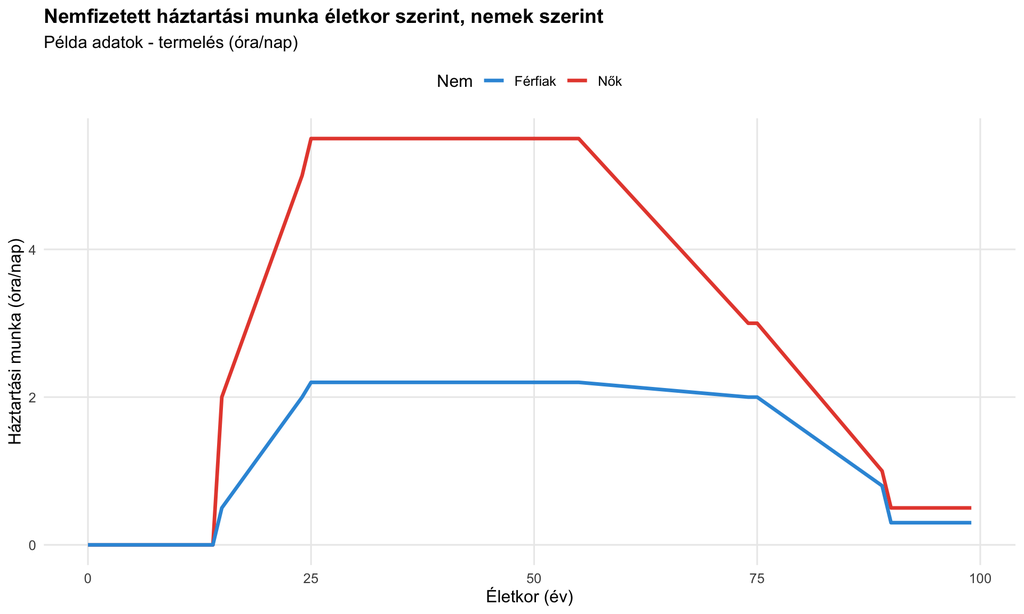

```r
# Vizualizáljuk a nemi bontású termelési profilokat

ggplot(production_data, aes(x = age)) +
  geom_line(aes(y = female_hours_per_day, color = "Nők"), linewidth = 1.2) +
  geom_line(aes(y = male_hours_per_day, color = "Férfiak"), linewidth = 1.2) +
  scale_color_manual(values = c("Nők" = "#E74C3C", "Férfiak" = "#3498DB")) +
  labs(
    title = "Nemfizetett háztartási munka életkor szerint, nemek szerint",
    subtitle = "Példa adatok - termelés (óra/nap)",
    x = "Életkor (év)",
    y = "Háztartási munka (óra/nap)",
    color = "Nem"
  ) +
  theme_minimal(base_size = 12) +
  theme(
    legend.position = "top",
    plot.title = element_text(face = "bold", size = 14),
    panel.grid.minor = element_blank()
  )
```

# 6. Súlyozott kombinálás

## 6.1 A kombinálás végrehajtása

Most alkalmazzuk a súlyozott átlagolási módszert:

```r
# Kombináljuk az adatokat
combined_data <- production_data %>%
  left_join(un_population %>% select(age, male, female), by = "age") %>%
  mutate(
    # Súlyozott átlag számítása
    combined_hours_per_day = (
      female_hours_per_day * female + male_hours_per_day * male
    ) / (female + male),

    # Egyszerű átlag (nem súlyozott) - összehasonlításhoz
    simple_average = (female_hours_per_day + male_hours_per_day) / 2,

    # Különbség a két módszer között
    difference = combined_hours_per_day - simple_average
  )

head(combined_data, 15)
```

|  | age | female_hours_per_day | male_hours_per_day | male | female | combined_hours_per_day | simple_average | difference |
| --- | --- | --- | --- | --- | --- | --- | --- | --- |
| 1 | 0 | 0 | 0 | 110000 | 1e+05 | 0 | 0 | 0 |
| 2 | 1 | 0 | 0 | 110000 | 1e+05 | 0 | 0 | 0 |
| 3 | 2 | 0 | 0 | 110000 | 1e+05 | 0 | 0 | 0 |
| 4 | 3 | 0 | 0 | 110000 | 1e+05 | 0 | 0 | 0 |
| 5 | 4 | 0 | 0 | 110000 | 1e+05 | 0 | 0 | 0 |
| 6 | 5 | 0 | 0 | 110000 | 1e+05 | 0 | 0 | 0 |
| 7 | 6 | 0 | 0 | 110000 | 1e+05 | 0 | 0 | 0 |
| 8 | 7 | 0 | 0 | 110000 | 1e+05 | 0 | 0 | 0 |
| 9 | 8 | 0 | 0 | 110000 | 1e+05 | 0 | 0 | 0 |
| 10 | 9 | 0 | 0 | 110000 | 1e+05 | 0 | 0 | 0 |

[output cut: 5 more lines]

```r
combined_data[40:50, ]
```

|  | age | female_hours_per_day | male_hours_per_day | male | female | combined_hours_per_day | simple_average | difference |
| --- | --- | --- | --- | --- | --- | --- | --- | --- |
| 40 | 39 | 5.5 | 2.2 | 105000 | 105000 | 3.850000 | 3.85 | 0.00000000 |
| 41 | 40 | 5.5 | 2.2 | 95000 | 100000 | 3.892308 | 3.85 | 0.04230769 |
| 42 | 41 | 5.5 | 2.2 | 95000 | 100000 | 3.892308 | 3.85 | 0.04230769 |
| 43 | 42 | 5.5 | 2.2 | 95000 | 100000 | 3.892308 | 3.85 | 0.04230769 |
| 44 | 43 | 5.5 | 2.2 | 95000 | 100000 | 3.892308 | 3.85 | 0.04230769 |
| 45 | 44 | 5.5 | 2.2 | 95000 | 100000 | 3.892308 | 3.85 | 0.04230769 |
| 46 | 45 | 5.5 | 2.2 | 95000 | 100000 | 3.892308 | 3.85 | 0.04230769 |
| 47 | 46 | 5.5 | 2.2 | 95000 | 100000 | 3.892308 | 3.85 | 0.04230769 |
| 48 | 47 | 5.5 | 2.2 | 95000 | 100000 | 3.892308 | 3.85 | 0.04230769 |
| 49 | 48 | 5.5 | 2.2 | 95000 | 100000 | 3.892308 | 3.85 | 0.04230769 |

[output cut: 1 more lines]

```r
tail(combined_data, 10)
```

|  | age | female_hours_per_day | male_hours_per_day | male | female | combined_hours_per_day | simple_average | difference |
| --- | --- | --- | --- | --- | --- | --- | --- | --- |
| 91 | 90 | 0.5 | 0.3 | 30000 | 50000 | 0.425 | 0.4 | 0.025 |
| 92 | 91 | 0.5 | 0.3 | 30000 | 50000 | 0.425 | 0.4 | 0.025 |
| 93 | 92 | 0.5 | 0.3 | 30000 | 50000 | 0.425 | 0.4 | 0.025 |
| 94 | 93 | 0.5 | 0.3 | 30000 | 50000 | 0.425 | 0.4 | 0.025 |
| 95 | 94 | 0.5 | 0.3 | 30000 | 50000 | 0.425 | 0.4 | 0.025 |
| 96 | 95 | 0.5 | 0.3 | 30000 | 50000 | 0.425 | 0.4 | 0.025 |
| 97 | 96 | 0.5 | 0.3 | 30000 | 50000 | 0.425 | 0.4 | 0.025 |
| 98 | 97 | 0.5 | 0.3 | 30000 | 50000 | 0.425 | 0.4 | 0.025 |
| 99 | 98 | 0.5 | 0.3 | 30000 | 50000 | 0.425 | 0.4 | 0.025 |
| 100 | 99 | 0.5 | 0.3 | 30000 | 50000 | 0.425 | 0.4 | 0.025 |

```r
# Összesítő statisztikák
data.frame(
  Mutató = c("Nők átlagos", "Férfiak átlagos", "Kombinált (súlyozott)", "Egyszerű átlag", "Különbség"),
  Óra_per_nap = c(
    mean(production_data$female_hours_per_day),
    mean(production_data$male_hours_per_day),
    weighted.mean(combined_data$combined_hours_per_day,
                  combined_data$female + combined_data$male),
    mean(combined_data$simple_average),
    weighted.mean(combined_data$combined_hours_per_day,
                  combined_data$female + combined_data$male) -
      mean(combined_data$simple_average)
  )
)
```

| Mutató | Óra_per_nap |
| --- | --- |
| Nők átlagos | 3.200000 |
| Férfiak átlagos | 1.445000 |
| Kombinált (súlyozott) | 2.505589 |
| Egyszerű átlag | 2.322500 |
| Különbség | 0.183089 |

## 6.2 Vizualizáció: Mind a három eloszlás

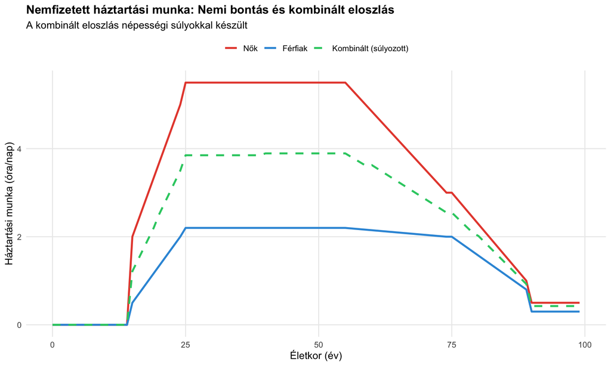

```r
# Hosszú formátumra alakítás a könnyebb ábrázoláshoz
plot_data <- combined_data %>%
  select(age, female_hours_per_day, male_hours_per_day, combined_hours_per_day) %>%
  pivot_longer(
    cols = c(female_hours_per_day, male_hours_per_day, combined_hours_per_day),
    names_to = "category",
    values_to = "hours"
  ) %>%
  mutate(
    category = case_when(
      category == "female_hours_per_day" ~ "Nők",
      category == "male_hours_per_day" ~ "Férfiak",
      category == "combined_hours_per_day" ~ "Kombinált (súlyozott)"
    ),
    category = factor(category, levels = c("Nők", "Férfiak", "Kombinált (súlyozott)"))
  )

ggplot(plot_data, aes(x = age, y = hours, color = category, linetype = category)) +
  geom_line(linewidth = 1.1) +
  scale_color_manual(
    values = c("Nők" = "#E74C3C", "Férfiak" = "#3498DB", "Kombinált (súlyozott)" = "#2ECC71")
  ) +
  scale_linetype_manual(
    values = c("Nők" = "solid", "Férfiak" = "solid", "Kombinált (súlyozott)" = "dashed")
  ) +
  labs(
    title = "Nemfizetett háztartási munka: Nemi bontás és kombinált eloszlás",
    subtitle = "A kombinált eloszlás népességi súlyokkal készült",
    x = "Életkor (év)",
    y = "Háztartási munka (óra/nap)",
    color = NULL,
    linetype = NULL
  ) +
  theme_minimal(base_size = 12) +
  theme(
    legend.position = "top",
    plot.title = element_text(face = "bold", size = 14),
    panel.grid.minor = element_blank()
  )
```

## 6.3 A súlyozás hatása különböző életkorokban

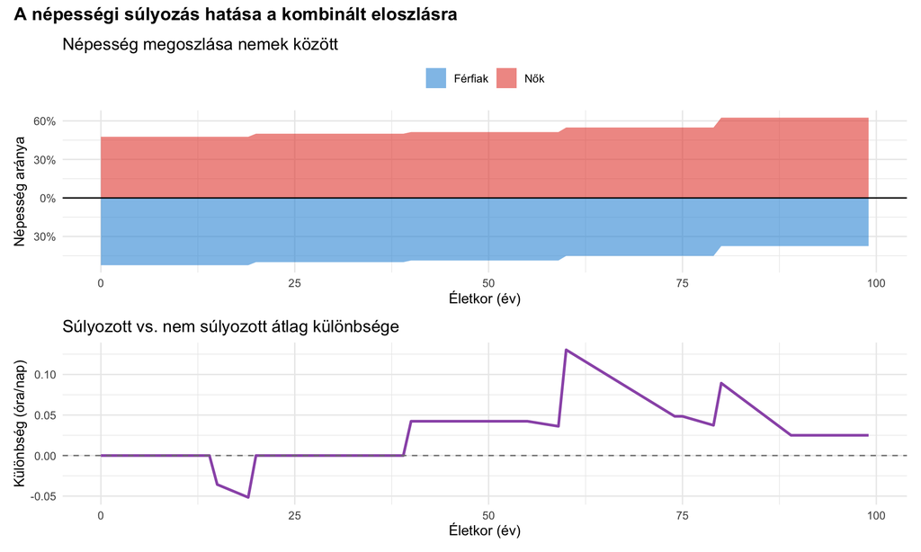

```r
# Népességi arányok nemek között
weight_data <- combined_data %>%
  mutate(
    female_proportion = female / (female + male),
    male_proportion = male / (female + male)
  )

# Két panel: népességi arány és a súlyozás hatása
p1 <- ggplot(weight_data, aes(x = age)) +
  geom_area(aes(y = female_proportion, fill = "Nők"), alpha = 0.6) +
  geom_area(aes(y = -male_proportion, fill = "Férfiak"), alpha = 0.6) +
  scale_fill_manual(values = c("Nők" = "#E74C3C", "Férfiak" = "#3498DB")) +
  geom_hline(yintercept = 0, color = "black", linewidth = 0.5) +
  scale_y_continuous(labels = function(x) paste0(abs(x) * 100, "%")) +
  labs(
    title = "Népesség megoszlása nemek között",
    x = "Életkor (év)",
    y = "Népesség aránya",
    fill = NULL
  ) +
  theme_minimal(base_size = 11) +
  theme(legend.position = "top")

p2 <- ggplot(combined_data, aes(x = age)) +
  geom_line(aes(y = difference), color = "#9B59B6", linewidth = 1) +
  geom_hline(yintercept = 0, linetype = "dashed", color = "gray50") +
  labs(
    title = "Súlyozott vs. nem súlyozott átlag különbsége",
    x = "Életkor (év)",
    y = "Különbség (óra/nap)"
  ) +
  theme_minimal(base_size = 11)

# Kombinált ábra
library(patchwork)
p1 / p2 +
  plot_annotation(
    title = "A népességi súlyozás hatása a kombinált eloszlásra",
    theme = theme(plot.title = element_text(face = "bold", size = 14))
  )
```

# 7. Értelmezés és következtetések

## 7.1 Főbb megfigyelések

```r
# Keressük meg a csúcsértékeket
female_peak <- production_data %>%
  filter(female_hours_per_day == max(female_hours_per_day)) %>%
  slice(1)

male_peak <- production_data %>%
  filter(male_hours_per_day == max(male_hours_per_day)) %>%
  slice(1)

combined_peak <- combined_data %>%
  filter(combined_hours_per_day == max(combined_hours_per_day)) %>%
  slice(1)

# Csúcsértékek táblázat
data.frame(
  Csoport = c("Nők", "Férfiak", "Kombinált"),
  Maximum_óra_per_nap = c(
    female_peak$female_hours_per_day,
    male_peak$male_hours_per_day,
    combined_peak$combined_hours_per_day
  ),
  Életkor = c(female_peak$age, male_peak$age, combined_peak$age)
)
```

| Csoport | Maximum_óra_per_nap | Életkor |
| --- | --- | --- |
| Nők | 5.500000 | 25 |
| Férfiak | 2.200000 | 25 |
| Kombinált | 3.892308 | 40 |

```r
# Teljes életúton végzett munka
female_total <- sum(production_data$female_hours_per_day)
male_total <- sum(production_data$male_hours_per_day)
combined_total <- sum(combined_data$combined_hours_per_day)

data.frame(
  Csoport = c("Nők", "Férfiak", "Kombinált"),
  Óra_összesen = c(female_total * 365, male_total * 365, combined_total * 365),
  Nap_összesen = c(female_total, male_total, combined_total),
  Év_összesen = c(female_total / 365, male_total / 365, combined_total / 365)
)
```

| Csoport | Óra_összesen | Nap_összesen | Év_összesen |
| --- | --- | --- | --- |
| Nők | 116800.00 | 320.0000 | 0.8767123 |
| Férfiak | 52742.50 | 144.5000 | 0.3958904 |
| Kombinált | 85862.21 | 235.2389 | 0.6444902 |

```r
# Nemi különbségek
female_work_total <- sum(production_data$female_hours_per_day * un_population$female)
male_work_total <- sum(production_data$male_hours_per_day * un_population$male)

data.frame(
  Mutató = c("Nők/Férfiak arány", "Nők által végzett munka aránya (%)"),
  Érték = c(
    female_total / male_total,
    100 * female_work_total / (female_work_total + male_work_total)
  )
)
```

| Mutató | Érték |
| --- | --- |
| Nők/Férfiak arány | 2.214533 |
| Nők által végzett munka aránya (%) | 71.284394 |

## 7.2 Módszertani megfigyelések

**1. A népességi súlyozás jelentősége:**

- A súlyozott kombináció **reálisabban tükrözi** a teljes népesség háztartási munka-termelését
- Különösen fontos idősebb korokban, ahol a nemek aránya jelentősen eltér
- Az egyszerű átlagolás **alulbecsülné** a női háztartási munka jelentőségét idősebb korban

**2. A súlyozás hatása életkoronként:**

```r
# Keressük meg, hol a legnagyobb a különbség
max_diff_age <- combined_data %>%
  filter(abs(difference) == max(abs(difference))) %>%
  slice(1)

data.frame(
  Mutató = "Legnagyobb különbség",
  Életkor = max_diff_age$age,
  Különbség_óra = max_diff_age$difference
)
```

| Mutató | Életkor | Különbség_óra |
| --- | --- | --- |
| Legnagyobb különbség | 60 | 0.1303905 |

```r
# Életkori csoportok szerinti összegzés
combined_data %>%
  mutate(
    age_group = case_when(
      age < 18 ~ "0-17: Gyermekkor",
      age < 35 ~ "18-34: Fiatal felnőtt",
      age < 55 ~ "35-54: Középkorú",
      age < 70 ~ "55-69: Idősebb aktív",
      TRUE ~ "70+: Időskor"
    )
  ) %>%
  group_by(age_group) %>%
  summarise(
    Nők_átlag = mean(female_hours_per_day),
    Férfiak_átlag = mean(male_hours_per_day),
    Kombinált_átlag = mean(combined_hours_per_day),
    Egyszerű_átlag = mean(simple_average),
    Különbség = mean(difference),
    .groups = "drop"
  )
```

| age_group | Nők_átlag | Férfiak_átlag | Kombinált_átlag | Egyszerű_átlag | Különbség |
| --- | --- | --- | --- | --- | --- |
| 0-17: Gyermekkor | 0.3888889 | 0.1111111 | 0.2433862 | 0.250000 | -0.006613757 |
| 18-34: Fiatal felnőtt | 4.8823529 | 1.9117647 | 3.3912232 | 3.397059 | -0.005835668 |
| 35-54: Középkorú | 5.5000000 | 2.2000000 | 3.8817308 | 3.850000 | 0.031730769 |
| 55-69: Idősebb aktív | 4.5789474 | 2.1263158 | 3.4350543 | 3.352632 | 0.082422765 |
| 70+: Időskor | 1.7105263 | 1.1368421 | 1.4682250 | 1.423684 | 0.044540787 |

**3. Miért fontos ez a módszertan?**

- **Gazdaságpolitikai szempontból**: A kombinált eloszlás pontosabb képet ad a teljes népesség háztartási munka-hozzájárulásáról, amely alapján GDP-korrekciókat lehet számolni
- **Társadalmi egyenlőség szempontjából**: Világosan mutatja a nemi különbségeket és azok életkori mintázatát
- **Demográfiai szempontból**: Figyelembe veszi a népesség szerkezetét, amely országonként és időben változik

# 8. Továbbfejlesztési lehetőségek

## 8.1 Valós adatok használata

Ez a példa demonstrációs adatokkal készült. Valós kutatáshoz:

1. **CWW adatbázisból** konkrét országot kiválasztani (pl. Vietnam, ahogy a feladatban szerepel)
2. **ENSZ népességi adatok letöltése** az adott országra és évre
3. **Időbeli változások** vizsgálata (pl. 2003 vs. 2010, ahogy a feladatban szerepel)

## 8.2 További elemzések

- **Több ország összehasonlítása**: Hogyan különböznek a minták fejlett vs. fejlődő országokban?
- **Pénzben mért értékek**: A háztartási munka gazdasági értékének számítása
- **Kohorsz-elemzés**: Ugyanazon korosztály követése időben
- **Oktatási szint szerint**: Miként befolyásolja a végzettség a háztartási munka-mintázatot?

## 8.3 Robusztusság-vizsgálat

- **Érzékenység-elemzés**: Mi történik, ha más népességi előrejelzéseket használunk?
- **Uncertainty quantification**: Konfidencia-intervallumok a becslésekhez
- **Bootstrap módszerek**: A statisztikai szignifikancia ellenőrzésére

# 9. Összefoglalás

## 9.1 Tanulságok

Ez a házifeladat bemutatja:

1. **Hogyan kombináljunk nemi bontású adatokat népességi súlyozással**
2. **Miért fontos a súlyozás** (nem egyenlő nemek aránya életkoronként)
3. **Hogyan értelmezhető** a kombinált eloszlás a nemi bontású eloszlásokhoz képest
4. **Milyen módszertani lépések** szükségesek egy ilyen elemzéshez

## 9.2 A módszer alkalmazhatósága

Ez a súlyozási módszer általánosan alkalmazható minden olyan helyzetben, amikor:

- Van két (vagy több) alcsoport adatunk
- Az alcsoportok mérete nem egyforma
- Teljes népességre vonatkozó becslést akarunk készíteni

Például: - **Regionális adatok** kombinálása országos szintre - **Különböző etnikai csoportok** adatainak összegzése - **Különböző foglalkozási csoportok** aggregálása

## 9.3 Forráskód elérhetősége

Ez a teljes RMarkdown dokumentum tartalmazza: - Az összes kódot az elemzés reprodukálásához - A módszertan részletes magyarázatát - Példa adatokat a logika bemutatásához

Valós adatokkal való futtatáshoz csak a `create_example_production()` és `create_example_population()` függvényeket kell lecserélni valós adatforrásokra.

# Hivatkozások

1. **Counting Women’s Work Database**: https://www.countingwomenswork.org/
2. **UN Population Division**: https://www.un.org/development/desa/pd/
3. **Eurostat HETUS**: https://ec.europa.eu/eurostat/web/time-use-surveys
4. **AGENTA Data Explorer**: http://dataexplorer.wittgensteincentre.org/nta/

*Készítve: 2025-12-02*